# Introduction

Aleksandr Fisher

# How Political Science Became Irrelevant

- what kind of research is useful?
- what kind of research should be prioritized?

# Data Types

- **Numeric**:
  - Discrete (can be counted)
  - Continuous (can’t be counted, i.e. decimals)
- **Categorical**:
  - generally not recorded as numbers
  - Party identification
- **Ordinal**:
  - categories with a specified order
  - think survey responses (strongly agree, somewhat agree,…)

# Cyanide and Happiness 2017 Politics Poll

# Looking at the Data (dim and glimpse)

```r
# dim
dim(cah) # number of rows, number of columns
```

```
## [1] 1000   19
```

```r
# glimpse
glimpse(cah) #observations, variables, and variable type
```

```
## Rows: 1,000
## Columns: 19
## $ Income                               <int> 192000, 54000, 20000, 21000, 1...
## $ Gender                               <fct> Female, Female, Male, Female, ...
## $ Age                                  <int> 35, 58, 50, 40, 42, 35, 82, 36...
## $ AgeRange                             <fct> 35-44, 55-64, 45-54, 35-44, 35...
## $ PoliticalAffiliation                 <fct> Strong Republican, Independent...
## $ ApproveTrump                         <fct> DK/REF, Disapprove, Approve, D...
## $ education                            <fct> College degree, Some college, ...
## $ race                                 <fct> White, White, White, White, Bl...
## $ AgreeWhiteNationalists               <fct> DK/REF, DK/REF, Agree, DK/REF,...
## $ RepublicansAgreeWhiteNationalists    <dbl> NA, NA, 10, NA, NA, 50, 70, 70...
## $ Would.you.say.that.you.love.America. <fct> Yes, Yes, Yes, Yes, Yes, Yes, ...
## $ DemocratsLoveAmerica                 <int> 40, 80, 60, 30, NA, 100, 75, 1...
## $ GovHelpPoor                          <fct> Yes, Yes, Yes, Yes, Yes, Yes, ...
## $ WhitePeopleRacist                    <fct> No, No, Yes, Yes, DK/REF, Yes,...
## $ CivilWarNextDecade                   <fct> Unlikely, Likely, Likely, Like...
## $ hunting                              <fct> No, No, Yes, No, No, No, No, N...
## $ kalesalad                            <fct> No, No, No, Yes, Yes, No, No, ...
## $ VoteTheRockPres                      <fct> No, Yes, Yes, No, Yes, No, No,...
## $ VaderOrTrump                         <fct> Donald Trump, Darth Vader, Don...
```

# Looking at the Data (head)

```r
# head
head(cah) # first 6 observations
```

```
##   Income Gender Age AgeRange PoliticalAffiliation ApproveTrump       education
## 1 192000 Female  35    35-44    Strong Republican       DK/REF  College degree
## 2  54000 Female  58    55-64          Independent   Disapprove    Some college
## 3  20000   Male  50    45-54  Not Strong Democrat      Approve           Other
## 4  21000 Female  40    35-44          Independent   Disapprove  College degree
## 5 164000 Female  42    35-44      Strong Democrat       DK/REF Graduate degree
## 6   9000 Female  35    35-44      Strong Democrat   Disapprove     High school
##     race AgreeWhiteNationalists RepublicansAgreeWhiteNationalists
## 1  White                 DK/REF                                NA
## 2  White                 DK/REF                                NA
## 3  White                  Agree                                10
## 4  White                 DK/REF                                NA
## 5  Black                 DK/REF                                NA
## 6 Latino                  Agree                                50
##   Would.you.say.that.you.love.America. DemocratsLoveAmerica GovHelpPoor
```

[output cut: 20 more lines]

# Numbers as data

- R can be used as a calculator

```r
2+2
```

```
## [1] 4
```

- Everything you will use in R is saved in objects.
  - This can be everything from a number or a word to complex datasets
- These are equivalent:

```r
x <- 2
x = 2
```

- Now `x` will return the number 2 whenever we write `x`

# Numbers as data

- When you are working with scripts, try to save as much you can in objects, so you only need to change information once

```r
y=x+7
y
```

```
## [1] 9
```

- Wrapping object in parenthesis tells R that we do not only want to save some information in the object y, but that we also want to see what is saved in y.

```r
(y=x+7)
```

```
## [1] 9
```

# More than one number

- Not limited to save only one number in an object.
- The code below will return a row of numbers from 1 to 10.

```r
1:10
```

```
##  [1]  1  2  3  4  5  6  7  8  9 10
```

# Getting the Basics

- Don’t forget to check and set your working directory
- R can’t find files that aren’t there

# Getting the Basics

- The Behavioral Risk Factor Surveillance System (BRFSS) is an annual telephone survey of 350,000 people in the United States. The BRFSS Web site contains a complete description of the survey, including the research questions that motivate the study and many interesting results derived from the data.

```r
library(tidyverse)
source("http://www.openintro.org/stat/data/cdc.R")
CDC <- tbl_df(cdc)
class(cdc)
```

```
## [1] "data.frame"
```

# Explore the data

- You can see and inspect the data set comfortably in RStudio with the View() command, which invokes a spreadsheet-style data viewer on a matrix-like R object.

```r
CDC
```

```
## # A tibble: 20,000 x 9
##    genhlth   exerany hlthplan smoke100 height weight wtdesire   age gender
##    <fct>       <dbl>    <dbl>    <dbl>  <dbl>  <int>    <int> <int> <fct>
##  1 good            0        1        0     70    175      175    77 m
##  2 good            0        1        1     64    125      115    33 f
##  3 good            1        1        1     60    105      105    49 f
##  4 good            1        1        0     66    132      124    42 f
##  5 very good       0        1        0     61    150      130    55 f
##  6 very good       1        1        0     64    114      114    55 f
##  7 very good       1        1        0     71    194      185    31 m
##  8 very good       0        1        0     67    170      160    45 m
##  9 good            0        1        1     65    150      130    27 f
## 10 good            1        1        0     70    180      170    44 m
## # ... with 19,990 more rows
```

# Explore the data

- After loading the data and converting it into a tibble, one should inspect the data to get some understanding about the structure and content. Common funtions for these tasks are:
- `<name-of-data-tibble>`: Display the first 10 rows and all columns that fit on one screen. It also prints an abbreviated description of the column type.
- `head(<name-of-df>)`, `tail(<name-of-df>)`: Return the first or last part. Use these commands if it is not a tibble but a data frame
- `dim()`: Retrieve the dimension
- `names()`: Get the names

# Explore the data

- `str()`: Display compactly the internal structure
- `glimpse()`: is the dplyr-version of str() showing values of each variable the whole sceen width, but does not display the number of levels and names of factor variables. But this feature of str() cannot be displayed completly with either many or long levels names.
- `View()`: With RStudio you can see and inspect the data set comfortably. The View() function invokes a spreadsheet-style data viewer.

# Install Packages

- When you download R from the Comprehensive R Archive Network (CRAN), you get that “base” R system
- The base R system comes with basic functionality; implements the R language
- One reason R is so useful is the large collection of packages that extend the basic functionality of R
- R packages are developed and published by the larger R community

# Install Packages

- Packages can be installed with the `install.packages()` function in R
- To install a single package, pass the name of the lecture to the install.packages() function as the first argument
- You can install multiple R packages at once with a single call to install.packages()
- `install.packages(c("dplyr", "ggplot2", "devtools"))`

# Loading R Packages

- Installing a package does not make it immediately available to you in R; you must load the package
- The library() function is used to load packages into R
- The following code is used to load the ggplot2 package into R

```r
library(ggplot2)
```

- NOTE: Do not put the package name in quotes!

# Arbuthnot Dataset

- The Arbuthnot data set refers to Dr. John Arbuthnot, an 18th century physician, writer, and mathematician. He was interested in the ratio of newborn boys to newborn girls, so he gathered the baptism records for children born in London for every year from 1629 to 1710. We can view the data by typing its name into the console.
- Read data from online with the code below:

```r
source("http://www.openintro.org/stat/data/arbuthnot.R")
```

# Look as Data

```r
dim(arbuthnot) #get number of rows and columns
```

```
## [1] 82  3
```

```r
glimpse(arbuthnot) #get the structure of the data
```

```
## Rows: 82
## Columns: 3
## $ year  <int> 1629, 1630, 1631, 1632, 1633, 1634, 1635, 1636, 1637, 1638, 1...
## $ boys  <int> 5218, 4858, 4422, 4994, 5158, 5035, 5106, 4917, 4703, 5359, 5...
## $ girls <int> 4683, 4457, 4102, 4590, 4839, 4820, 4928, 4605, 4457, 4952, 4...
```

# Look as Data

```r
names(arbuthnot)
```

```
## [1] "year"  "boys"  "girls"
```

```r
#We can access the data in a single column of a data frame separately.
arbuthnot$boys
```

```
##  [1] 5218 4858 4422 4994 5158 5035 5106 4917 4703 5359 5366 5518 5470 5460 4793
## [16] 4107 4047 3768 3796 3363 3079 2890 3231 3220 3196 3441 3655 3668 3396 3157
## [31] 3209 3724 4748 5216 5411 6041 5114 4678 5616 6073 6506 6278 6449 6443 6073
## [46] 6113 6058 6552 6423 6568 6247 6548 6822 6909 7577 7575 7484 7575 7737 7487
## [61] 7604 7909 7662 7602 7676 6985 7263 7632 8062 8426 7911 7578 8102 8031 7765
## [76] 6113 8366 7952 8379 8239 7840 7640
```

# Plot Data - Base R

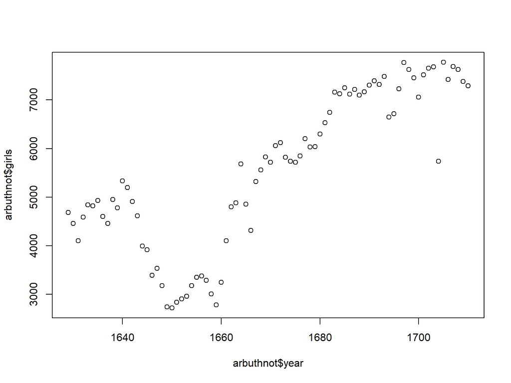

```r
plot(x = arbuthnot$year, y = arbuthnot$girls)
```

# Plot Data - qplot R

- R has some powerful functions for making graphics. We can create a simple plot of the number of girls baptized per year with qplot.

```r
qplot(x = year, y = girls, data = arbuthnot)
```

# Plot Data - qplot R

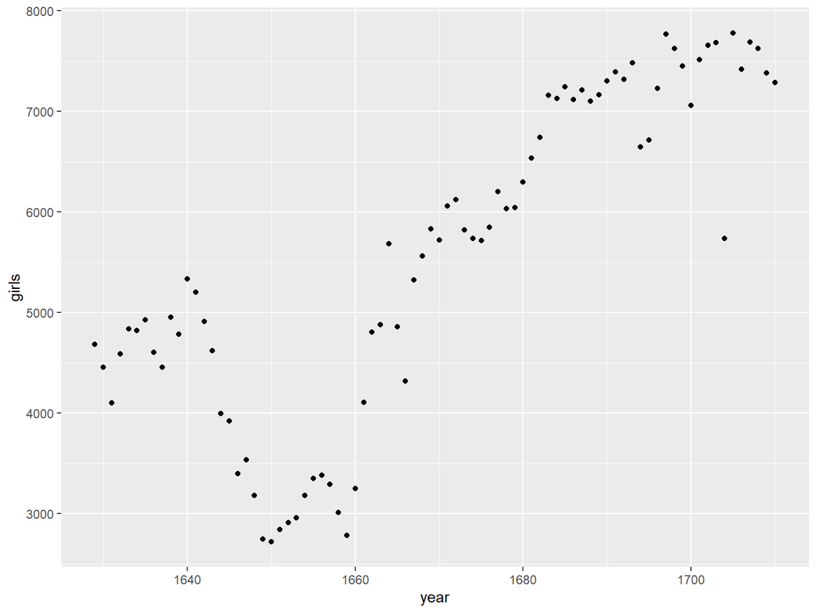

# Plot Data - line graph

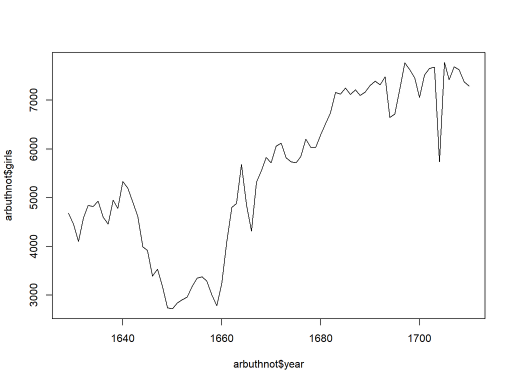

```r
plot(x = arbuthnot$year, y = arbuthnot$girls, type = "l")
```

# Plot Data - line graph

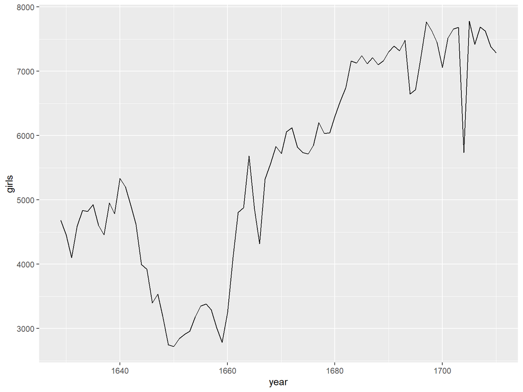

```r
qplot(x = year, y = girls, data = arbuthnot, geom = "line")
```

# Manipulating Data - Creating New Variables

- Now, suppose we want to plot the total number of baptisms. To compute this, we could use the fact that R is really just a big calculator. We can type in mathematical expressions like

```r
5218 + 4683
```

```
## [1] 9901
```

```r
arbuthnot$boys + arbuthnot$girls
```

```
##  [1]  9901  9315  8524  9584  9997  9855 10034  9522  9160 10311 10150 10850
## [13] 10670 10370  9410  8104  7966  7163  7332  6544  5825  5612  6071  6128
## [25]  6155  6620  7004  7050  6685  6170  5990  6971  8855 10019 10292 11722
## [37]  9972  8997 10938 11633 12335 11997 12510 12563 11895 11851 11775 12399
## [49] 12626 12601 12288 12847 13355 13653 14735 14702 14730 14694 14951 14588
## [61] 14771 15211 15054 14918 15159 13632 13976 14861 15829 16052 15363 14639
## [73] 15616 15687 15448 11851 16145 15369 16066 15862 15220 14928
```

# Manipulating Data - Creating New Variables (mutate)

- We’ll be using this new vector to generate some plots, so we’ll want to save it as a permanent column in our data frame.

```r
arbuthnot <- arbuthnot %>%
  mutate(total = boys + girls)
```

# Piping Operator

- The `%>%` operator is called the piping operator. It takes the output of the previous expression and pipes it into the first argument of the function in the following one. To continue our analogy with mathematical functions, `x %>% f(y)` is equivalent to `f(x, y)`.

# Piping Operator

# Manipulating Data - Adding in plot

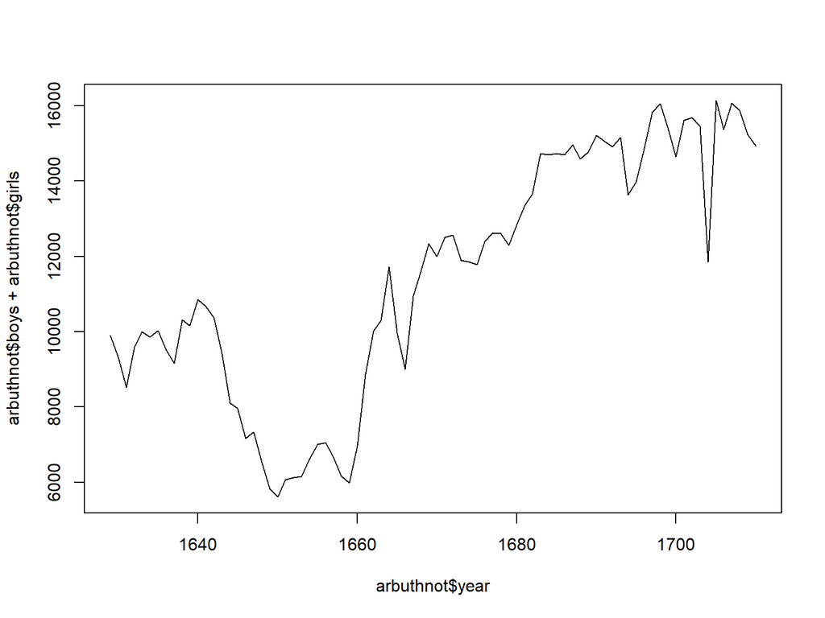

```r
plot(arbuthnot$year, arbuthnot$boys + arbuthnot$girls, type = "l")
```

# Manipulating Data - Adding in qplot

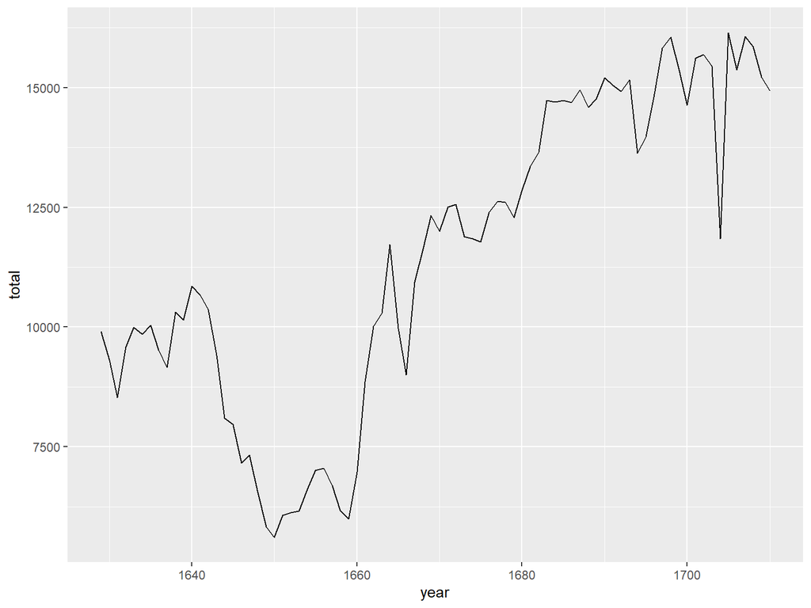

```r
qplot(x = year, y = total, data = arbuthnot, geom = "line")
```

# Manipulating Data - creating ratios

```r
5218 / 4683
```

```
## [1] 1.114243
```

# Manipulating Data - creating ratios

```r
arbuthnot$boys / arbuthnot$girls
```

```
##  [1] 1.114243 1.089971 1.078011 1.088017 1.065923 1.044606 1.036120 1.067752
##  [9] 1.055194 1.082189 1.121656 1.034884 1.051923 1.112016 1.038120 1.027521
## [17] 1.032661 1.109867 1.073529 1.057215 1.121267 1.061719 1.137676 1.107290
## [25] 1.080095 1.082416 1.091371 1.084565 1.032533 1.047793 1.153901 1.146905
## [33] 1.156075 1.085988 1.108584 1.063369 1.052697 1.083121 1.055242 1.092266
## [41] 1.116143 1.097744 1.064016 1.052778 1.043112 1.065354 1.059647 1.120575
## [49] 1.035467 1.088679 1.034100 1.039530 1.044237 1.024466 1.058536 1.062860
## [57] 1.032846 1.064054 1.072498 1.054359 1.060974 1.083128 1.036526 1.039092
## [65] 1.025792 1.050850 1.081931 1.055748 1.037981 1.104904 1.061594 1.073219
## [73] 1.078254 1.048981 1.010673 1.065354 1.075460 1.072132 1.090022 1.080808
## [81] 1.062331 1.048299
```

```r
arbuthnot <- arbuthnot %>%
  mutate(boy_to_girl_ratio = boys / girls)
```

# Manipulating Data - ratios using mutate

```r
arbuthnot <- arbuthnot %>%
  mutate(boy_ratio = boys / total)
```

# Manipulating Data - True/False

```r
arbuthnot$boys > arbuthnot$girls
```

```
##  [1] TRUE TRUE TRUE TRUE TRUE TRUE TRUE TRUE TRUE TRUE TRUE TRUE TRUE TRUE TRUE
## [16] TRUE TRUE TRUE TRUE TRUE TRUE TRUE TRUE TRUE TRUE TRUE TRUE TRUE TRUE TRUE
## [31] TRUE TRUE TRUE TRUE TRUE TRUE TRUE TRUE TRUE TRUE TRUE TRUE TRUE TRUE TRUE
## [46] TRUE TRUE TRUE TRUE TRUE TRUE TRUE TRUE TRUE TRUE TRUE TRUE TRUE TRUE TRUE
## [61] TRUE TRUE TRUE TRUE TRUE TRUE TRUE TRUE TRUE TRUE TRUE TRUE TRUE TRUE TRUE
## [76] TRUE TRUE TRUE TRUE TRUE TRUE TRUE
```

# Manipulating Data

# Adding Labels to our plots

- To add a title to your plot, add the code:
  - `+ggtitle("Your Title Here")` to your line of basic ggplot code.
- Note: You can also use:
  - `+labs(title = "Title"`)`
- To alter the labels on the axis, add the code:
  - `+labs(y= "y axis name", x = "x axis name")`
- Can also use:
  - `+xlab("x axis name"` and `+ylab("y axis name")`

# Adding Labels to our plots

```r
arbuthnot %>% ggplot(aes(year, total)) +
        geom_line() +
        xlab("Year") + ylab("Baptized children (boys and girls)") +
        ggtitle("Baptized children, born in London. Recorded by Dr. John Arbuthnot.")
```

# Adding Labels to our plots

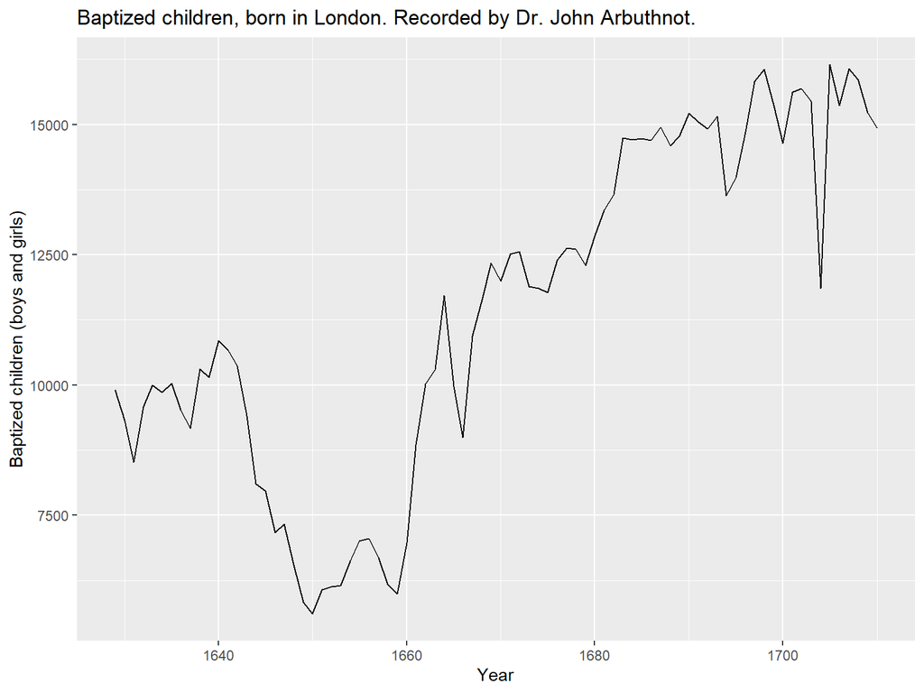

# Ratio Plot

- Similarly to how we computed the total number of births, we can compute different kinds of ratios (boys to girls, boys to total, girls to total).

```r
arbuthnot <- arbuthnot %>%
  mutate(boy_to_girl_ratio = boys / girls)

arbuthnot %>%
        ggplot(aes(year, boy_to_girl_ratio)) +
        geom_line() +
        xlab("Year") + ylab("Baptized ratio (boys to girls)") +
        ggtitle("Baptized children, born in London. Recorded by Dr. John Arbuthnot.")
```

# Ratio Plot

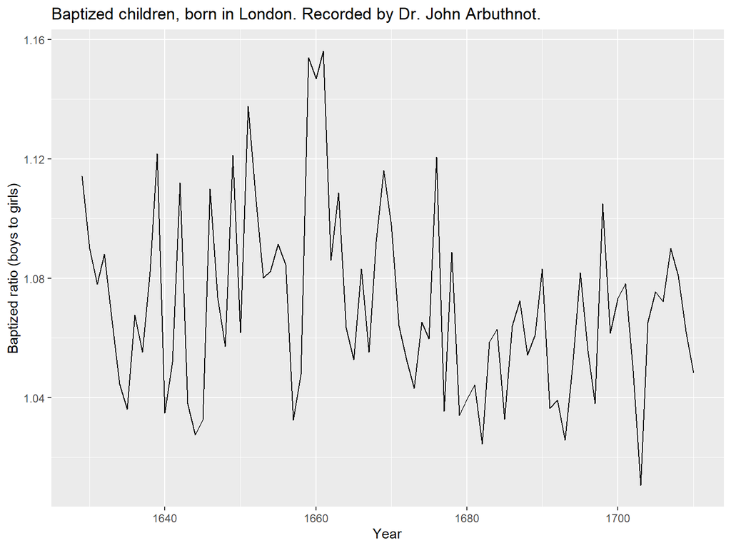